# QUARTETO DE ANSCOMBE - Análises

Maria Eduarda Mesquita Magalhães

2023-05-07

# 1 O que é o Quarteto de Anscombe?

Criado pelo estatístico britânico Francis Anscombe, o quarteto de anscombe é um conjunto de quatro grupos de dados que possuem as mesmas propriedades estatísticas descritivas (como média, desvio padrão e correlação), mas apresentam padrões completamente diferentes quando visualizados graficamente.

Esses conjuntos de dados foram criados para enfatizar a importância da visualização de dados na análise estatística e para alertar sobre a confiança excessiva em resumos numéricos sem a devida investigação dos padrões de dados subjacentes.

### 1.0.1 Quem foi Francis Anscombe?

Nascido em 1918, foi um estatístico nascido em Hove, Inglaterra. Ele fez contribuições significativas em diversas áreas da estatística, incluindo análise de variância, regressão, análise de séries temporais e estatística computacional.

Foi mundialmente reconhecido pela criação do quarteto que leva o seu nome. Anscombe trabalhou como professor na Universidade de Cambridge e na Universidade de Princeton e foi presidente da Sociedade de Estatística Real de 1973 a 1975. Ele foi um dos primeiros usuários do computador na estatística, desenvolvendo métodos para análise estatística e simulação por computador.Faleceu em 2001 deixando um grande legado para o estudo da estatística.

# 2 Importando a biblioteca

```r
library(ggplot2)
```

# 3 Importando o conjunto de dados

```r
anscombe
```

```
##    x1 x2 x3 x4    y1   y2    y3    y4
## 1  10 10 10  8  8.04 9.14  7.46  6.58
## 2   8  8  8  8  6.95 8.14  6.77  5.76
## 3  13 13 13  8  7.58 8.74 12.74  7.71
## 4   9  9  9  8  8.81 8.77  7.11  8.84
## 5  11 11 11  8  8.33 9.26  7.81  8.47
## 6  14 14 14  8  9.96 8.10  8.84  7.04
## 7   6  6  6  8  7.24 6.13  6.08  5.25
## 8   4  4  4 19  4.26 3.10  5.39 12.50
## 9  12 12 12  8 10.84 9.13  8.15  5.56
## 10  7  7  7  8  4.82 7.26  6.42  7.91
## 11  5  5  5  8  5.68 4.74  5.73  6.89
```

# 4 Visualizando uma amostra do conjunto de dados

```r
head(anscombe)
```

```
##   x1 x2 x3 x4   y1   y2    y3   y4
## 1 10 10 10  8 8.04 9.14  7.46 6.58
## 2  8  8  8  8 6.95 8.14  6.77 5.76
## 3 13 13 13  8 7.58 8.74 12.74 7.71
## 4  9  9  9  8 8.81 8.77  7.11 8.84
## 5 11 11 11  8 8.33 9.26  7.81 8.47
## 6 14 14 14  8 9.96 8.10  8.84 7.04
```

# 5 Visualizando o resumo descritivo dos conjuntos em estudo

```r
summary(anscombe)
```

```
##        x1             x2             x3             x4           y1
##  Min.   : 4.0   Min.   : 4.0   Min.   : 4.0   Min.   : 8   Min.   : 4.260
##  1st Qu.: 6.5   1st Qu.: 6.5   1st Qu.: 6.5   1st Qu.: 8   1st Qu.: 6.315
##  Median : 9.0   Median : 9.0   Median : 9.0   Median : 8   Median : 7.580
##  Mean   : 9.0   Mean   : 9.0   Mean   : 9.0   Mean   : 9   Mean   : 7.501
##  3rd Qu.:11.5   3rd Qu.:11.5   3rd Qu.:11.5   3rd Qu.: 8   3rd Qu.: 8.570
##  Max.   :14.0   Max.   :14.0   Max.   :14.0   Max.   :19   Max.   :10.840
##        y2              y3              y4
##  Min.   :3.100   Min.   : 5.39   Min.   : 5.250
##  1st Qu.:6.695   1st Qu.: 6.25   1st Qu.: 6.170
##  Median :8.140   Median : 7.11   Median : 7.040
##  Mean   :7.501   Mean   : 7.50   Mean   : 7.501
##  3rd Qu.:8.950   3rd Qu.: 7.98   3rd Qu.: 8.190
##  Max.   :9.260   Max.   :12.74   Max.   :12.500
```

## 5.1 Média dos conjuntos em estudo

```r
mean(anscombe$x1)
```

```
## [1] 9
```

```r
mean(anscombe$x2)
```

```
## [1] 9
```

```r
mean(anscombe$x3)
```

```
## [1] 9
```

```r
mean(anscombe$x4)
```

```
## [1] 9
```

```r
mean(anscombe$y1)
```

```
## [1] 7.500909
```

```r
mean(anscombe$y2)
```

```
## [1] 7.500909
```

```r
mean(anscombe$y3)
```

```
## [1] 7.5
```

```r
mean(anscombe$y4)
```

```
## [1] 7.500909
```

## 5.2 Mediana dos conjuntos em estudo

```r
median(anscombe$x1)
```

```
## [1] 9
```

```r
median(anscombe$x2)
```

```
## [1] 9
```

```r
median(anscombe$x3)
```

```
## [1] 9
```

```r
median(anscombe$x4)
```

```
## [1] 8
```

```r
median(anscombe$y1)
```

```
## [1] 7.58
```

```r
median(anscombe$y2)
```

```
## [1] 8.14
```

```r
median(anscombe$y3)
```

```
## [1] 7.11
```

```r
median(anscombe$y4)
```

```
## [1] 7.04
```

## 5.3 Desvio padrão dos conjuntos em estudo

```r
sd(anscombe$x1)
```

```
## [1] 3.316625
```

```r
sd(anscombe$x2)
```

```
## [1] 3.316625
```

```r
sd(anscombe$x3)
```

```
## [1] 3.316625
```

```r
sd(anscombe$x4)
```

```
## [1] 3.316625
```

```r
sd(anscombe$y1)
```

```
## [1] 2.031568
```

```r
sd(anscombe$y2)
```

```
## [1] 2.031657
```

```r
sd(anscombe$y3)
```

```
## [1] 2.030424
```

```r
sd(anscombe$y4)
```

```
## [1] 2.030579
```

# 6 Gráficos

O argumento aes(x = …, y = …), define as variáveis que serão plotadas no eixo x e y, respectivamente. A função geom_point() adiciona os pontos ao gráfico e ggtitle() define o título do gráfico.

## 6.1 Gráfico 1

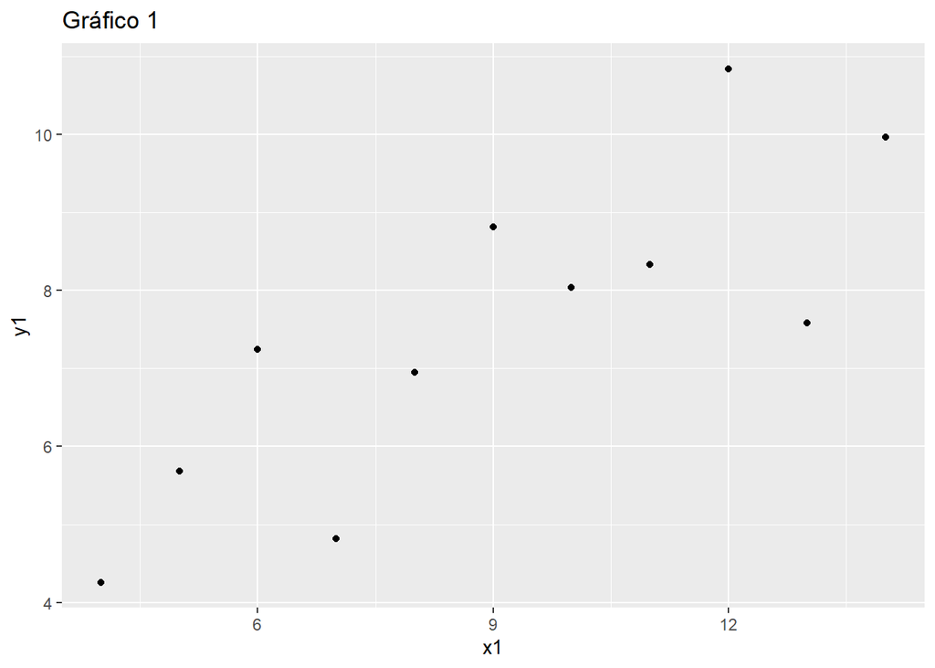

```r
ggplot(anscombe, aes(x = x1, y = y1)) +
  geom_point() +
  ggtitle("Gráfico 1")
```

## 6.2 Gráfico 2

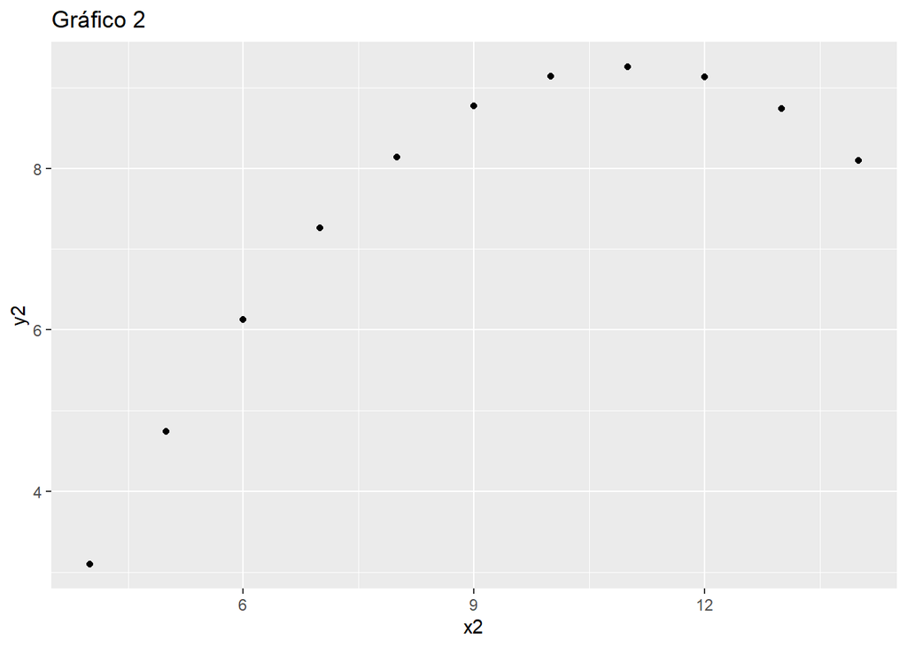

```r
ggplot(anscombe, aes(x = x2, y = y2)) +
  geom_point() +
  ggtitle("Gráfico 2")
```

## 6.3 Gráfico 3

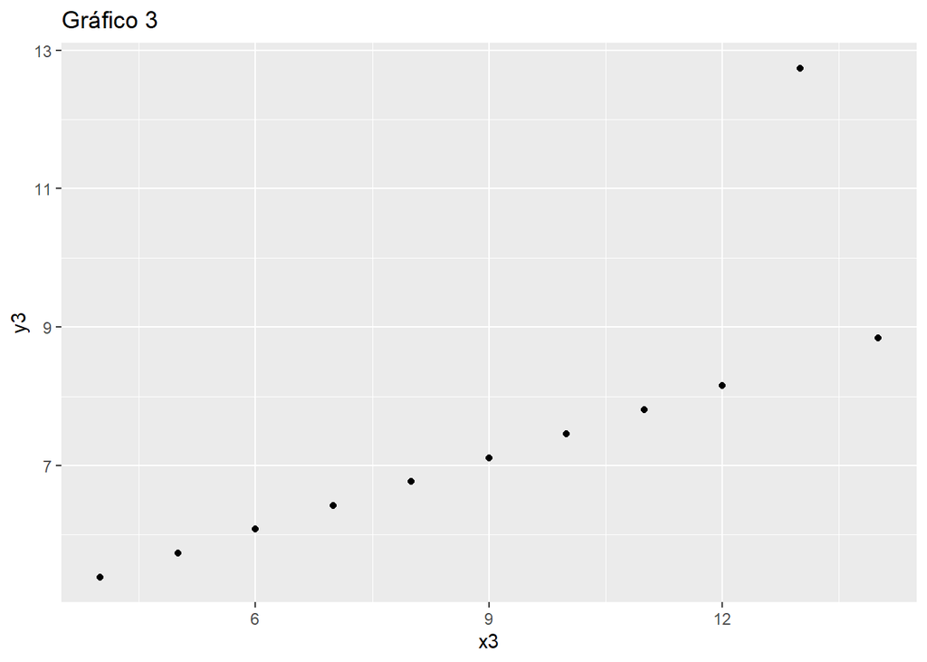

```r
ggplot(anscombe, aes(x = x3, y = y3)) +
  geom_point() +
  ggtitle("Gráfico 3")
```

## 6.4 Gráfico 4

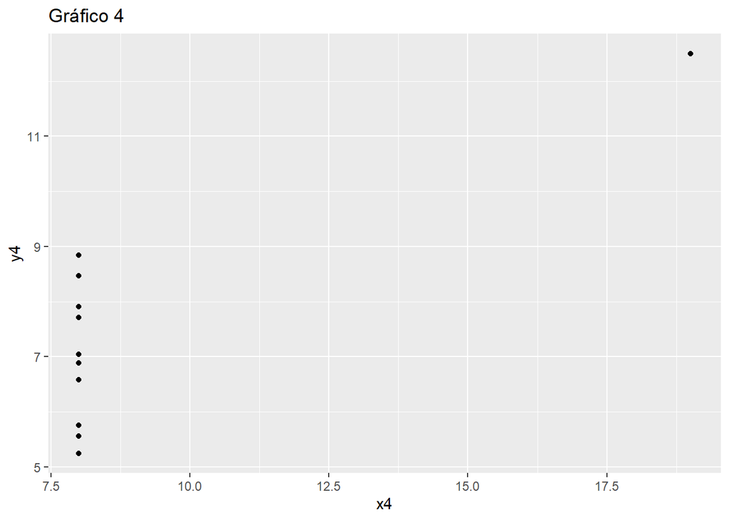

```r
ggplot(anscombe, aes(x = x4, y = y4)) +
  geom_point() +
  ggtitle("Gráfico 4")
```

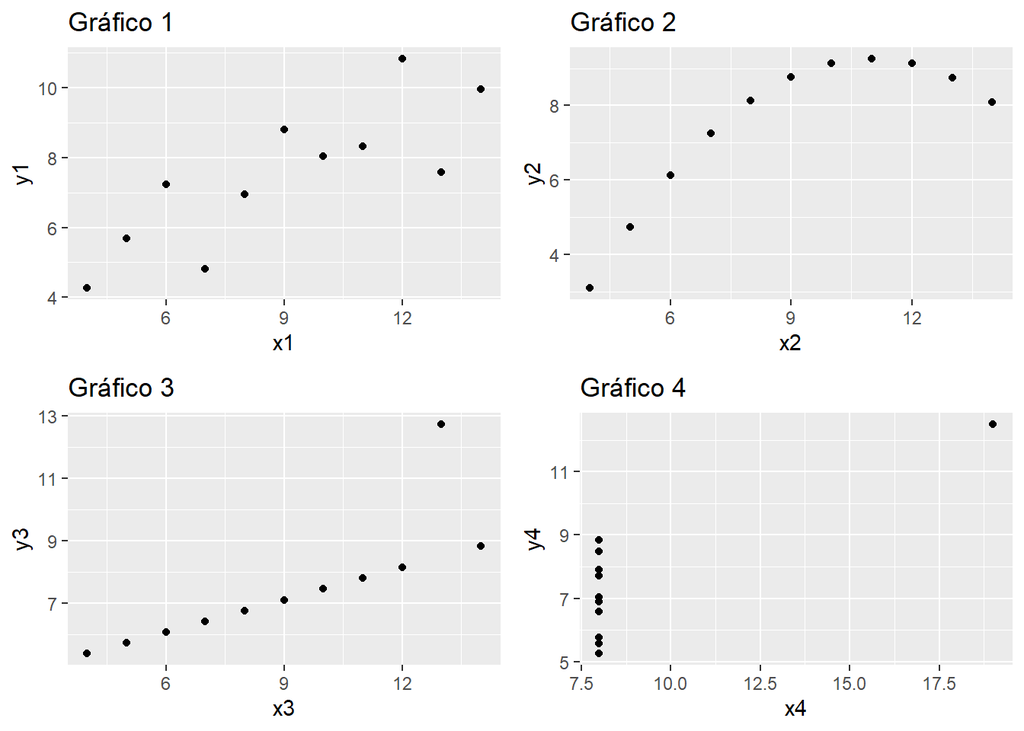

```r
library(gridExtra)

# Gráfico 1
p1 <- ggplot(anscombe, aes(x = x1, y = y1)) +
  geom_point() +
  ggtitle("Gráfico 1")

# Gráfico 2
p2 <- ggplot(anscombe, aes(x = x2, y = y2)) +
  geom_point() +
  ggtitle("Gráfico 2")

# Gráfico 3
p3 <- ggplot(anscombe, aes(x = x3, y = y3)) +
  geom_point() +
  ggtitle("Gráfico 3")

# Gráfico 4
p4 <- ggplot(anscombe, aes(x = x4, y = y4)) +
  geom_point() +
  ggtitle("Gráfico 4")

# Organiza os quatro gráficos em uma matriz 2x2
grid.arrange(p1, p2, p3, p4, ncol = 2)
```

# 7 Linha de tendência

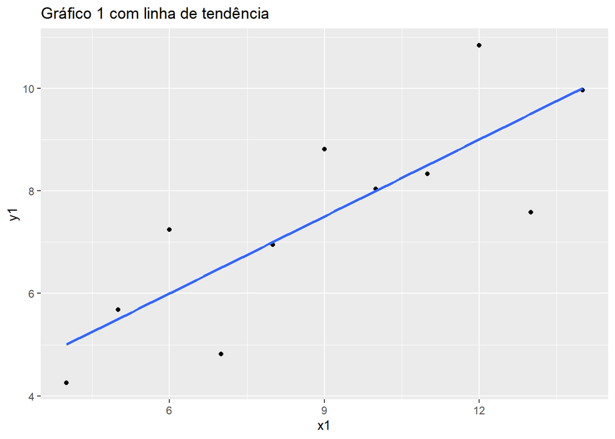

```r
library(stringi)

ggplot(anscombe, aes(x = x1, y = y1)) +
  geom_point() +
  geom_smooth(method = "lm", se = FALSE) +
  ggtitle(stri_encode("Gráfico 1 com linha de tendência", "UTF-8"))
```

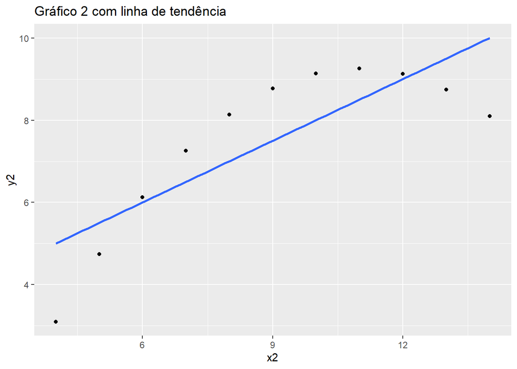

```r
ggplot(anscombe, aes(x = x2, y = y2)) +
  geom_point() +
  geom_smooth(method = "lm", se = FALSE) +
  ggtitle(stri_encode("Gráfico 2 com linha de tendência", "UTF-8"))
```

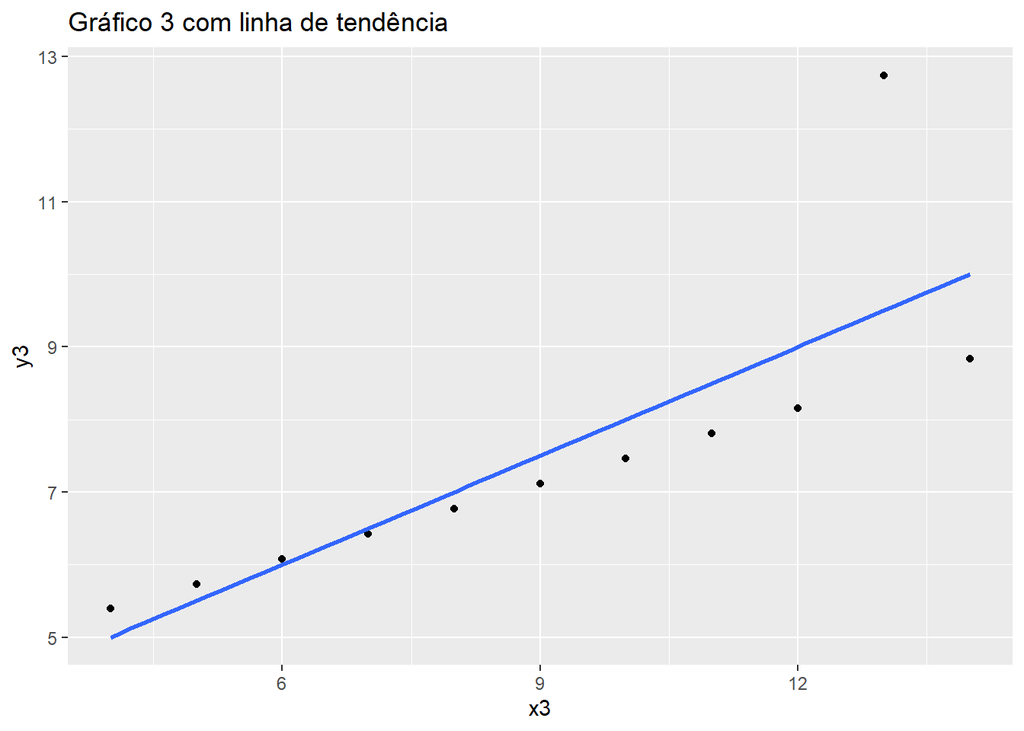

```r
ggplot(anscombe, aes(x = x3, y = y3)) +
  geom_point() +
  geom_smooth(method = "lm", se = FALSE) +
  ggtitle(stri_encode("Gráfico 3 com linha de tendência", "UTF-8"))
```

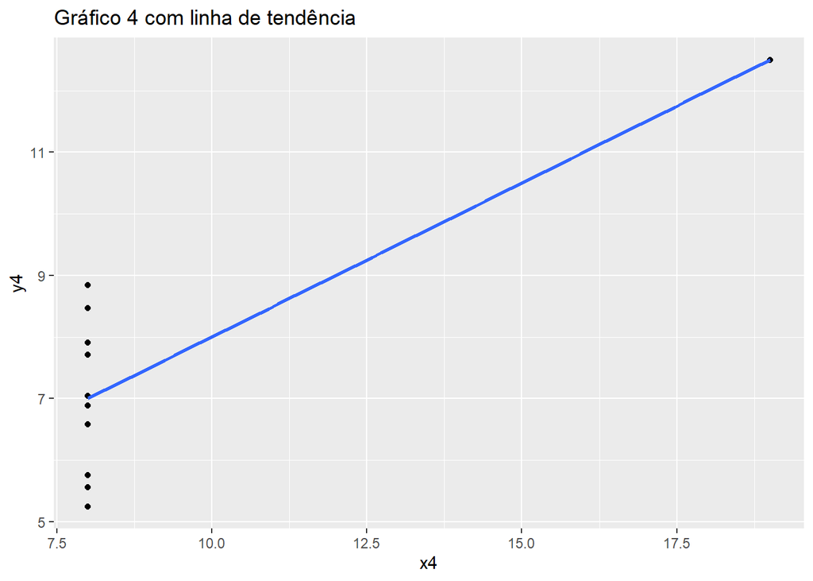

```r
ggplot(anscombe, aes(x = x4, y = y4)) +
  geom_point() +
  geom_smooth(method = "lm", se = FALSE) +
  ggtitle(stri_encode("Gráfico 4 com linha de tendência", "UTF-8"))
```

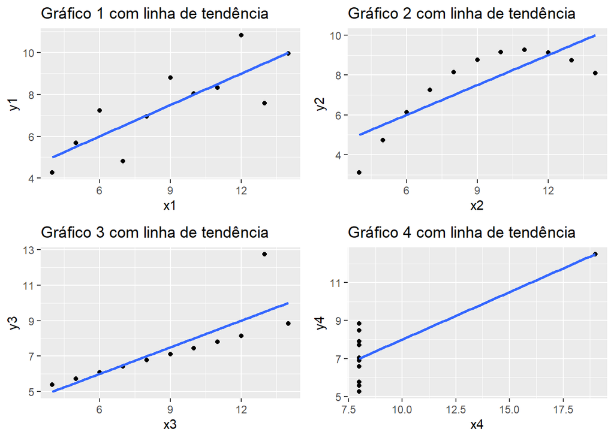

```r
a <- p1 + geom_smooth(method = "lm", se = FALSE) + ggtitle(stri_encode("Gráfico 1 com linha de tendência", "UTF-8"))
b <- p2 + geom_smooth(method = "lm", se = FALSE) + ggtitle(stri_encode("Gráfico 2 com linha de tendência", "UTF-8"))
c <- p3 + geom_smooth(method = "lm", se = FALSE) + ggtitle(stri_encode("Gráfico 3 com linha de tendência", "UTF-8"))
d <- p4 + geom_smooth(method = "lm", se = FALSE) + ggtitle(stri_encode("Gráfico 4 com linha de tendência", "UTF-8"))

grid.arrange(a,b,c,d, ncol = 2)
```